# HHL Algorithm

HHL Algorithm first introduced in the paper [*Quantum algorithm for linear systems of equations*](https://arxiv.org/abs/0811.3171) by Aram W. Harrow, Avinatan Hassidim, Seth Lloyd is named after three researchers behinds its developement. The HHL algorithm attempts to solve the linear equation $A \boldsymbol{x} = \boldsymbol{b}$. It is important to recognize that while the HHL algorithm provides the means to reconstruct the normalized solution $\frac{x}{\|x\|}$ up to a global phase, recovering the full classical vector would vanish the quantum advantage of the algorithm, as it would require $\mathcal{O}(N)$ measurements, where $N$ is the dimension of $x$. The HHL algorithm is typically used as a subroutine within a larger quantum algorithm. If employed as a standalone procedure, one must carefully restrict attention to global properties or specific statistical features of $x$ that can be estimated efficiently from the quantum state. We will examine these subtleties in this tutorial and clarify that the output of the HHL algorithm is the quantum state $|x\rangle$, rather than the classical vector $\frac{x}{\|x\|}$, which is different.

It is worth noting that the [arXiv entry of the HHL paper](https://arxiv.org/abs/0811.3171) contains three versions, dated 19 November 2008 (v1), 3 February 2009 (v2), and 30 September 2009 (v3). The journal publication appeared in [Physical Review Letters](https://journals.aps.org/prl/abstract/10.1103/PhysRevLett.103.150502) on 7 October 2009. The three arXiv versions differ in depth and presentation. Version 2 includes a more detailed analysis compared to the initial submission, while Version 3 includes further refinements and editorial improvements prior to journal publication. Interestingly, the first two versions were titled "Quantum algorithm for solving linear systems of equations", whereas the third version adopted the shorter title "Quantum algorithm for linear systems of equations", omitting the word "solving." This change may reflect a more clear acknowledgment that HHL produces a quantum state proportional to the solution vector, rather than directly yielding the full classical solution. For the purposes of this tutorial and to avoid ambiguity, any reference to "the original HHL paper" or "the HHL paper" will refer to Version 3 of the arXiv preprint.

In this tutorial, we will begin by defining the statement of the problem that the HHL algorithm is trying to solve, and then introduce the relevant definitions and language needed to express the requirements of the algorithm. We will cover the said requirements, present the algorithm itself, and then unpack the intricacies of the algorithm. We will explain what the algorithm outputs, compare it with classical counterparts and follow-ups to the HHL algorithm, discuss its applications, and go over a simplified implementation of the algorithm in Qiskit while touching on methodologies for overcoming challenges in the implementation of the algorithm.

1. Quantum Linear System Problem
2. Input Assumptions
3. Overview of Algorithm
4. The HHL Description
5. Uncomputation Trick
6. Normalization Constant
7. Number of Iterations
8. Output of HHL
9. Time Complexity
10. Applications and Extensions of HHL
11. Implementation of HHL algorithm
12. Conclusion

### Appendices

13. Appendix 1: Clock Register Nomenclature
14. Appendix 2: Biography
15. Appendix 3: References and Suggested Readings

### Quantum Linear System Problem

We begin by defining the Linear System Problem (LSP) and its quantum counterpart, the Quantum Linear System Problem (QLSP), as adapted from [Quantum linear systems algorithms: a primer](https://arxiv.org/abs/1802.08227) by Dervovic et al.

**Definition - Linear System Problem**

Given a matrix $A \in \mathbb{C}^{N \times N}$ and a vector $b \in \mathbb{C}^{N}$, output a vector $x \in \mathbb{C}^N$ such that $Ax=b$, or a flag indicating the system has no solution.

**Definition - Quantum Linear System Problem**

Let $A$ be an $N \times N$ Hermitian matrix with unit determinant (as the authors note, this condition can be relaxed). Let $b$ and $x$ be $N$-dimensional vectors such that $x \coloneqq A^{-1}b$.Define the quantum state on $\lceil \log(N) \rceil$ qubits $$ |b\rangle = \frac{\sum_i b_i |i\rangle}{\| \sum_i b_i |i\rangle \|_2}, $$ and similarly $$ |x\rangle = \frac{\sum_i x_i |i\rangle}{\| \sum_i x_i |i\rangle \|_2}, $$ where $b_i$ and $x_i$ are respectively the $i^{\text{th}}$ components of vectors $b$ and $x$, respectively. Given the matrix $A$ and the state $|b \rangle$, output a state $|\tilde{x} \rangle$ such that $\| |\tilde{x} \rangle - |x\rangle \|_2 \leq \epsilon$ with some probability larger than $\frac{1}{2}$. Note that in practice, we will introduce a "flag" qubit which will determine whether or not this process has been successful.

A Quantum Linear System Algorithm (QLSA) is a quantum algorithm that solves the QLSP. The HHL algorithm is an instance of a QLSA, although several QLSAs have been developed since HHL.

An important distinction between LSP and QLSP, as already mentioned and which is evident from the definitions, is that LSP outputs the vector $x$, whereas QLSP returns the quantum state $|x\rangle$. Thus, while the two problems are closely related, their outputs differ, making direct comparison somewhat challenging.

Moreover, the HHL algorithm relies on additional structural assumptions about the input matrix, such as sparsity, bounds on the condition number, and the efficient preparation of the input state, which will be discussed later.

A relevant question is how the QLSP can be rephrased to make the comparison more direct with classical counterparts. To enable direct comparison with classical algorithms, the QLSP can be reformulated as an expectation value estimation problem:

> Given $Ax = b$, estimate $$ \langle x | O | x \rangle = x^\dagger O x$$ for observable $O$.

In this formulation, the output is classical, making the comparison more direct. The observable $O$ should be efficiently measurable and should not require full state tomography.

### Input Assumptions

The HHL Algorithm makes certain assumtpion about the input system to make the computations possible. We briefly touch upon the assumptions next:

- The Matrix $A$ is required to be Hermitian. That is, the matrix $A$ has to equal its conjugate transpose: $A = A^{\dagger}$. If $A$ is not Hermitian, then it can be embedded into a Hermitian matrix by constructing $$\tilde{A} = \begin{bmatrix} 0 & A \\ A^\dagger & 0 \end{bmatrix} = \tilde{A}^\dagger,$$ which satisfies $\tilde{A} = \tilde{A}^{\dagger}$. That is, $\tilde{A}$ is Hermitian. In this case, one instead solves the linear system $$\tilde{A} y = \begin{pmatrix} b \\ 0 \end{pmatrix}.$$ Hermiticity is required to ensure $e^{i At}$ is a unitary matrix, which is important for the implementation of the HHL algorithm.
- Efficient implementation of $e^{i At}$ requires that the matrix $A$ be sparse. A matrix $A \in \mathbb{C}^{N \times N}$ is said to be $s$-sparse if each row has at most $s$ nonzero entries.
- The HHL algorithm performs better when the matrix $A$ has a low condition number. The condition quantifies the sensitivity of the solution of a linear system to perturbations in the input. To understand the condition number, we familiarize ourselves with the notions of operator norm, spectral norm (a specific instance of the operator norm), singular values and their relation to eigenvalues, and how these concepts combine in the special case of Hermitian matrices.

**Definition of Operator Norm**

Given a vector norm $\| \cdot \|$, the corresponding operator norm of a matrix $A$ is defined as $$\| A \| \coloneqq \sup\limits_{v \neq 0} \frac{ \| Av \| }{\| v \|}.$$

Equivalently: $$\| A \| = \sup\limits_{\| v \| = 1} \| Av \|.$$

The equivalence relationship follows since for every nonzero $v$, there exists a unit vector $u = \frac{v}{\| v \|}$ such that

$$ \frac{ \| Av \| }{\| v \|} = \| Au \| .$$

The operator norm $\| A \|$ represents the largest stretching factor that the matrix $A$ applies to a unit vector under the chosen vector norm.

**Definition of Spectral Norm**

The spectral norm is the operator norm induced by the Euclidean (2-)norm:

$$\| A \|_2 = \sup\limits_{\| v \|_2 = 1} \| Av \|_2.$$

This is the matrix norm implicitly used throughout the HHL algorithm.

**Definition of Singular Values**

For any matrix $A \in \mathbb{C}^{m \times n}$, the singular values of $A$ are defined as:

$$ \sigma_i (A) \coloneqq \sqrt{ \lambda_i \left( A^\dagger A \right) },$$

where $\lambda_i ( \cdot )$ is the $i^{\text{th}}$ eigenvalue of the matrix inside the parentheses, so $\lambda_i(A^\dagger A)$ means the $i^{\text{th}}$ eigenvalue of the matrix $A^{\dagger} A$.

This definition is well-defined because $A^{\dagger} A$ is Hermitian and positive semidefinite for any matrix $A$, which means that its eigenvalues are real and nonnegative.

From this definition, it follows $$ \| A \|_2 = \sigma_{\max} (A) $$ and, if $A$ is invertible, $$ \| A^{-1} \|_2 = \frac{1}{\sigma_{\min}(A)}.$$ Moreover, if $A$ is Hermitian, then its singular values are simply the absolute values of its eigenvalues: $$ \sigma_i(A) = | \lambda_i(A) |.$$

**Definintion of Condition Number**

The condition number of an invertible matrix $A$ with respect to the spectral norm is defined as: $$ \kappa(A) \coloneqq \| A \| \cdot \| A^{-1} \|.$$

For Hermitian matrices, this reduces to $$\kappa(A) = \frac{\sigma_{\max}(A)}{\sigma_{\min}(A)} = \frac{| \lambda_{\max}(A) | }{ |\lambda_{\min}(A)| }.$$

which is the definition used in the HHL paper.

Consider the system $Ax = b$ perturbed to $A\tilde{x} = b + \delta b$. Then:

$$A(\tilde{x} - x) = \delta b \implies \tilde{x} - x = A^{-1}\delta b$$

Taking norms and using $\|Av\| \leq \|A\| \cdot \|v\|$ (which follows directly from the definition of $\|A\|$): $$\|\tilde{x} - x\| = \|A^{-1}\delta b\| \leq \|A^{-1}\| \cdot \|\delta b\|$$

From $\|b\| = \|Ax\| \leq \|A\| \cdot \|x\|$, we get $\|x\| \geq \|b\|/\|A\|$. Combining these:

$$\frac{\|\tilde{x} - x\|}{\|x\|} \leq \frac{\|A^{-1}\| \cdot \|\delta b\|}{\|b\|/\|A\|} = \|A\| \cdot \|A^{-1}\| \cdot \frac{\|\delta b\|}{\|b\|} = \kappa(A) \cdot \frac{\|\delta b\|}{\|b\|}$$

A high condition number $\kappa(A)$ means small relative errors in $b$ get amplified by factor $\kappa(A)$ in the solution $x$. For instance, if $\kappa = 1000$ and $\|\delta b\|/\|b\| = 0.001$ (0.1% input error), then the output error could be as large as $\|\tilde{x} - x\|/\|x\| \leq 1$ (100% error).

The algorithm assumes singular values (equivalently, the magnitudes of the eigenvalues) of $A$ lie in the interval $[1/\kappa, 1]$ to ensure numerical stability, and the runtime scales as $\tilde{O}(\kappa^2 s^2 \log(N)/\epsilon)$, where $\tilde{O}$ notation suppresses more slowly-growing terms.

- The algorithm also assume that the vector $|b \rangle$ can be efficiently prepared. Efficient state prepration is not trivial.

### Overview of Algorithm

Given that $A$ is Hermitian, by spectral decomposition: $A = \sum\limits_{i=0}^{N-1} \lambda_i | u_i \rangle \langle u_i |$ where $\{ |u_i \rangle \}_{i=0}^{N-1}$ is an eigenbasis of $A$. The solution $|b \rangle$ written in the same eigenbasis yields: $|b\rangle = \sum\limits_{i=0}^{N-1} b_i | u_i \rangle$. Hence, solving $A |x\rangle = |b\rangle$ yields: $$ \begin{aligned} | x \rangle &= \frac{A^{-1} |b\rangle}{\| A^{-1} |b \rangle \|_2} \\ &= \frac{1}{ \| A^{-1} |b \rangle \|_2 } \sum\limits_{i=0}^{N-1} \frac{1}{\lambda_i} | u_i \rangle \langle u_i | \sum\limits_{j=0}^{N-1} b_j | u_j \rangle \\ &= \frac{1}{\sqrt{\sum\limits_{i=0}^{N-1} \frac{|b_i|^2}{\lambda_i^2}}} \sum\limits_{i = 0}^{N - 1} \frac{b_i}{\lambda_i} |u_i \rangle. \end{aligned} $$ The algorithm works by preparing the input state $|b\rangle$ and extracting the eigenvalues of matrix $A$ by means of Hamiltonian simulation through Quantum Phase Estimation (QPE), performing eigenvalue inversion, and then some additional complementary steps, including uncomputation, which will be explained later, to extract the solution $|x\rangle \propto A^{-1}|b\rangle$ as a quantum state.

The algorithm uses three registers: an ancilla qubit, a clock register, and the input data register.

Then our initial state is $|0\rangle_{S} \otimes |0\rangle_{C} \otimes |0\rangle_{I}$ where subscripts $\{ S, C, I \}$ represent the corresponding registers in the entire state, with $S$ corresponding to the ancilla qubit, $C$ to the clock register, and $I$ to the input state, which will hold the state $|b\rangle$.

On the clock and input registers, we apply QPE. In textbook QPE, we apply Hadamard gates as a common choice of window function, which we call Hadamard-based QPE. However, that is not the only choice for a window function, as there are other choices such as the sine window function, defined by $\sqrt{ \frac{2}{N} } \sum\limits_{\tau=0}^{N-1} \sin\left( \frac{\pi(\tau+\frac{1}{2})}{N} \right) |\tau\rangle$. See [A case study against QSVT: assessment of quantum phase estimation improved by signal processing techniques](https://arxiv.org/abs/2404.01396) for more on the choice of window function. For the purposes of this tutorial and implementation, we will focus on Hadamard-based QPE, while noting that the original HHL algorithm stated the sine window function as an optimal choice, with detailed derivation and error analysis available in [Quantum linear systems algorithms: a primer](https://arxiv.org/abs/1802.08227) by Dervovic et al.

### The HHL Description

We present the algorithm next.

**1. Register Setup and Initialization**

The algorithm uses three quantum registers:

- $S$: Single-qubit success register
- $C$: $n_c$-qubit clock (phase) register
- $I$: $n_d$-qubit input register

The algorithm begins with all registers initialized to $| 0 \rangle$:

$$ | \Psi_0 \rangle = |0\rangle_S \otimes |0\rangle_C^{\otimes n_c} \otimes |0\rangle_I^{\otimes n_{d}} $$

We assume access to a state-preparation unitary $U_b$ that prepares the input state: $$ |b\rangle_I = \sum\limits_{j=0}^{2^{n_d} - 1} b_j |u_j \rangle_I, $$ from the computational basis state $|0\rangle^{\otimes n_d}_I$.

Prepare the input state:

$$ | \Psi_0 \rangle = |0\rangle_S \otimes |0\rangle_C^{\otimes n_c} \otimes |0\rangle_I^{\otimes n_{d}} \xrightarrow{U_b \text{ on } I} |0 \rangle_S |0\rangle_C^{\otimes n_c} \otimes |b \rangle_{I} = |\Psi_1 \rangle. $$

**2. Quantum Phase Estimation (QPE)**

We perform Hadamard-based quantum phase estimation using $U = e^{iAt}$.

Hadamard gates are applied to all qubits of the clock register $C$, preparing a uniform superposition,

$$ |\Psi_1\rangle = |0\rangle_S |0\rangle_C^{\otimes n_c} \sum_{j} b_j |u_j\rangle_I \;\xrightarrow{H^{\otimes n_c} \text{ on } C}\; |0\rangle_S \left( \frac{1}{\sqrt{2^{n_c}}} \sum_{k=0}^{2^{n_c}-1} |k\rangle_C \right) \sum_{j=0}^{2^{n_d} - 1} b_j |u_j\rangle_I = |\Psi_2\rangle. $$

Next, for each qubit $m$ in register $C$, where $m=0, \dots, n_c - 1$, apply a controlled-$U^{2^m}$ gate with the $m^{\text{th}}$ clock qubit as control and register $I$ as target. Since $A | u_j \rangle = \lambda_j | u_j \rangle$, we have: $$ U | u_j \rangle = e^{i \lambda_j t} | u_j \rangle. $$

The eigenphase associated with each eigenvalue is: $$ \phi_j = \frac{\lambda_j t}{2 \pi}. $$ The application of controlled-$U^{2^m}$ sequence produces the phase kickback $$|k\rangle_C |u_j \rangle \mapsto e^{i k \lambda_j t} |k\rangle_C |u_j \rangle_I,$$ where $k$ is the integer represented by the clock register. The joint state becomes $$ |\Psi_2 \rangle = |0\rangle_S \left( \frac{1}{\sqrt{2^{n_c}}} \sum_{k=0}^{2^{n_c}-1} |k\rangle_C \right) \sum_{j=0}^{2^{n_d} - 1} b_j |u_j\rangle_I \xrightarrow{\text{controlled-}U^{2^m} \text{ for $m \in \{ 0, 1, \ldots, n_c - 1 \}$ on } (C,I)} |0\rangle_S \ \frac{1}{\sqrt{2^{n_c}}} \sum\limits_{k=0}^{2^{n_c} - 1} \sum\limits_{j=0}^{2^{n_d} - 1} b_j e^{2 \pi i k \phi_j} |k \rangle_C |u_j \rangle_I = | \Psi_3 \rangle. $$

Applying the inverse quantum Fourier transform $\mathrm{QFT}^{\dagger}$ to register $C$ to extract the phase information yields $$ |\Psi_3 \rangle = |0\rangle_S \frac{1}{\sqrt{2^{n_c}}} \sum\limits_{k=0}^{2^{n_c} - 1} \sum\limits_{j=0}^{2^{n_d} - 1} b_j e^{i k \lambda_j t} |k \rangle_C |u_j \rangle_I \xrightarrow{\mathrm{QFT}^\dagger \text{ on } C} |0\rangle_S \sum\limits_{j=0}^{2^{n_d} - 1} b_j | \tilde{\phi}_j \rangle_C | u_j \rangle_I = |\Psi_4 \rangle .$$ Here, $|\tilde{\phi}_j \rangle_C$ denotes the computational basis state in register $C$ that encodes an $n_c$-bit approximation to the eigenphase $\phi_j$. If this state corresponds to integer $m_j \in \{ 0,1,\dots, 2^{n_c} -1 \}$, then: $$ \tilde{\phi}_j = \frac{m_j}{2^{n_c}} \approx \phi_j. $$

The QPE output $| \tilde{\phi}_j \rangle$ encodes phase information, but we need eigenvalues for the rotation step. We recover the eigenvalue estimate through the relation: $$ \tilde{\lambda}_j = \frac{2 \pi}{t} \tilde{\phi}_j = \frac{2 \pi}{t} \cdot \frac{m_j}{2^{n_c}}. $$

Thus, we can notationally rewrite the state after QPE as: $$ |\Psi_4 \rangle = |0\rangle_S \otimes \sum\limits_{j = 0}^{2^{n_d} - 1} b_j | \tilde{\lambda}_j \rangle_C \otimes |u_j \rangle_I. $$ where by $| \tilde{\lambda}_j \rangle_C$, we mean the same computational basis state $|\tilde{\phi}_j \rangle_C$, but now interpreted as encoding the eigenvalue estimate $\tilde{\lambda}_j$.

**3. Eigenvalue Inversion via Controlled Rotation**

We now apply a rotation to the ancilla qubit $S$, controlled by the clock register $C$. For each eigenvalue estimate, define: $$ \theta_j = 2 \arcsin \left( \frac{M}{\tilde{\lambda}_j} \right), $$ where $M$ is a normalization factor such that $M = \mathcal{O} \left(\frac{1}{\kappa} \right)$.

The single-qubit rotation gate is: $$ R_y(\theta) = e^{-i \theta Y/2} = \begin{bmatrix} \cos\left(\frac{\theta}{2}\right) & -\sin\left(\frac{\theta}{2}\right) \\ \sin\left(\frac{\theta}{2}\right) & \cos\left(\frac{\theta}{2}\right) \end{bmatrix}, $$ which acts on the success register $S$.

Define the controlled-rotation unitary:

$$ U_{\text{ContRot}} = \sum\limits_{k = 0}^{2^{n_c} - 1} R_y (\theta_k)_S \otimes |k\rangle \langle k |_C \otimes I_I, $$ where $\theta_k = 2 \arcsin \left( \frac{M}{\tilde{\lambda}_k} \right)$ with $\tilde{\lambda}_k$ being the eigenvalue estimate encoded by $|k\rangle$.

Recall the state after QPE:

$$ |0\rangle_S \sum\limits_{j=0}^{2^{n_d} - 1} b_j | \tilde{\lambda}_j \rangle_C | u_j \rangle_I $$ where $| \tilde{\lambda}_j \rangle_C = |k_j \rangle_C$ for some $k_j \in \{ 0,1,\dots, 2^{n_c} - 1 \}$.

Consider a fixed eigenvector term index $j$. For this term, $|\tilde{\lambda}_j \rangle_C = |k_j \rangle_C$, and the controlled rotation applies $R_y(\theta_{k_j})$ to the ancilla:

$$ U_{\text{ContRot}} (|0\rangle_S |k_j \rangle_C |u_j \rangle_I) = R_y(\theta_{k_j})|0\rangle_S \otimes |k_j \rangle_C \otimes | u_j \rangle_I $$

Substituting the definition of $\theta_{k_j} = 2 \arcsin \left( \frac{M}{\tilde{\lambda}_{k_j}} \right)$: $$ \sin \left( \frac{\theta_{k_j}}{2} \right) = \sin \left[ \frac{ 2 \arcsin \left( \frac{M}{\tilde{\lambda}_{k_j}} \right)}{2} \right] = \sin \left[ \arcsin \left( \frac{M}{\tilde{\lambda}_{k_j}} \right) \right] = \frac{M}{\tilde{\lambda}_{k_j}}, $$ and therefore $$ \cos\left( \frac{\theta_{k_j}}{2} \right) = \sqrt{1 - \sin^2 \left( \frac{\theta_{k_j}}{2} \right)} = \sqrt{ 1 - \frac{M^2}{\tilde{\lambda}^2_{k_j}}} $$

so the fixed-term transformation is $$ |0 \rangle |\tilde{\lambda}_j \rangle | u_j \rangle_I \xrightarrow{U_{\text{ContRot}} \text{ on } (S,C)} \left( \sqrt{1 - \frac{M^2}{\tilde{\lambda}_j^2}} | 0 \rangle_S + \frac{M}{\tilde{\lambda}_j} |1\rangle_S \right) | \tilde{\lambda}_j \rangle_C | u_j \rangle_I. $$ The state after applying the controlled rotation operation is $$ | \Psi_4 \rangle = |0\rangle_S \sum\limits_{j=0}^{2^{n_d} - 1} b_j | \tilde{\lambda}_j \rangle_C | u_j \rangle_I \xrightarrow{U_{\text{ContRot}} \text{ on } (S,C)} \sum\limits_{j=0}^{2^{n_d} - 1} b_j \left( \sqrt{1 - \frac{M^2}{\tilde{\lambda}_j^2}} | 0 \rangle_S + \frac{M}{\tilde{\lambda}_j} |1\rangle_S \right) | \tilde{\lambda}_j \rangle_C | u_j \rangle_I = | \Psi_5 \rangle. $$

**4. Uncomputation**

Next, we uncompute the phase estimation by applying $\mathrm{QPE}^{\dagger}$ to $(C,I)$, returning the clock register to $|0 \rangle_C^{\otimes n_c}$: $$ |\Psi_5 \rangle = \sum\limits_{j=0}^{2^{n_d} - 1} b_j \left( \sqrt{1 - \frac{M^2}{\tilde{\lambda}_j^2}} | 0 \rangle_S + \frac{M}{\tilde{\lambda}_j} |1\rangle_S \right) | \tilde{\lambda}_j \rangle_C | u_j \rangle_I \xrightarrow{\mathrm{QPE}^{\dagger} \text{ on } (C,I)} \sum\limits_{j=0}^{2^{n_d} - 1} b_j \left( \sqrt{1 - \frac{M^2}{\tilde{\lambda}_j^2}} | 0 \rangle_S + \frac{M}{\tilde{\lambda}_j} |1\rangle_S \right) | 0\rangle_C^{\otimes n_c} | u_j \rangle_I = |\Psi_6 \rangle. $$

**5. Measurement and Postselection**

Measure register $S$ in the computational basis. Conditioning on outcome $|1\rangle_S$ , the remaining state, registers $C$ and $I$, collapses to:

$$ |\Psi_6 \rangle = \sum\limits_{j=0}^{2^{n_d} - 1} b_j \left( \sqrt{1 - \frac{M^2}{\tilde{\lambda}_j^2}} | 0 \rangle_S + \frac{M}{\tilde{\lambda}_j} |1\rangle_S \right) | 0\rangle_C^{\otimes n_c} | u_j \rangle_I \xrightarrow{\text{ Measure $S$ and postselect $|1 \rangle$}} \sqrt{\frac{1}{\sum\limits_j M^2 |b_j|^2/ |\tilde{\lambda}_j|^2}} \sum\limits_j b_j \frac{M}{\tilde{\lambda}_j} | 0 \rangle^{\otimes n_c}_C |u_j \rangle_I = |\Psi_7 \rangle. $$

Discarding the clock register leaves the approximate solution: $$ | \tilde{x} \rangle_I = \frac{\sum\limits_j \frac{b_j}{\tilde{\lambda}_j} | u_j \rangle}{ \sqrt{ \sum\limits_{j} \frac{|b_j|^2}{|\tilde{\lambda}_j|^2} } } \approx \frac{ A^{-1} |b\rangle_I }{ \left\| A^{-1} |b\rangle_I \right\| } = | x \rangle_I $$ where $\tilde{\lambda}_j$ are the eigenvalue estimates from QPE with $n_c$ qubits of precision, yielding an approximate quantum state solution to $|x\rangle = A^{-1}|b\rangle$.

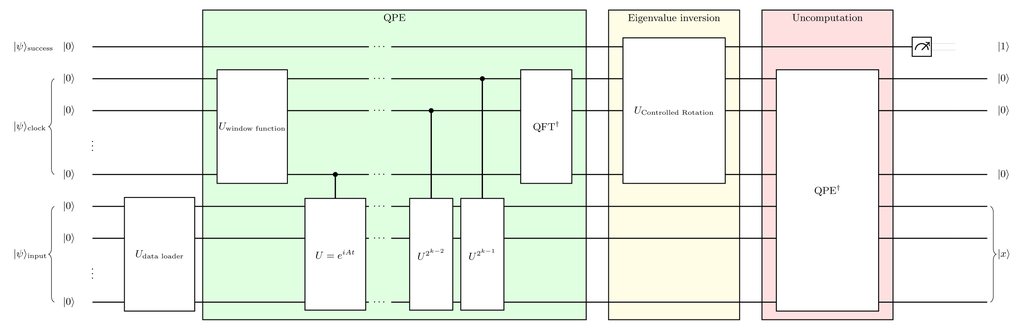

**Figure 1:** The HHL circuit consisting of success, clock, and input registers. First, the data is loaded into the input register, then QPE is applied between the clock and input registers, where the choice of window function is specified by the unitary $U_{\text{window function}}$. Hadamard gates are a common choice of window function. Then eigenvalue inversion is performed. In practice, this may rely on other subroutines. Lastly, $\text{QPE}^{\dagger}$ is applied for uncomputation, followed by measurement on the success register, with the solution stored as a quantum state in the input register upon measuring $|1\rangle$ on the success register..

### Uncomputation Trick

In HHL algorithm, after applying QPE and controlled rotation, the phase estimation procedure is undone by applying the inverse unitary $\mathrm{QPE}^{\dagger}$ to the clock register. This technique is commonly referred to as 'uncomputation trick', and its objective is to return the clock register to the computational basis state $|0 \rangle^{\otimes n_c}$. To understand why this step is essential, we first examine what happens if $\mathrm{QPE}^{\dagger}$ is not applied and the ancilla qubit is measured immediately after the controlled rotation.

Recall that the joint state of the system immediately before applying $\mathrm{QPE}^{\dagger}$ is $$ | \Psi_5 \rangle = \sum\limits_{j=0}^{2^{n_d} - 1} b_j \left( \sqrt{1 - \frac{M^2}{\tilde{\lambda}_j^2}} | 0 \rangle_S + \frac{M}{\tilde{\lambda}_j} |1\rangle_S \right) | \tilde{\lambda}_j \rangle_C | u_j \rangle_I $$

Conditioning on measuring the ancilla qubit in the state $|1\rangle_S$ yields the postselected state $$ |\Psi'_6 \rangle = \sqrt{\frac{1}{\sum\limits_j M^2 |b_j|^2/ |\tilde{\lambda}_j|^2}} \sum\limits_j b_j \frac{M}{\tilde{\lambda}_j} | \tilde{\lambda}_j \rangle_C |u_j \rangle_I. $$

Since distinct eigenvalues correspond to orthogonal clock states, $$ \langle \tilde{\lambda}_j | \tilde{\lambda}_{j'} \rangle = \delta_{jj'}, $$ the clock and input registers remain entangled. Consequently, the joint state is not separable.

Letting

$$ \alpha_j = \sqrt{\frac{1}{\sum\limits_j M^2 |b_j|^2/ |\tilde{\lambda}_j|^2}} b_j \frac{M}{\tilde{\lambda}_j}, $$

we may write

$$ |\Psi'_6 \rangle = \sum\limits_j \alpha_j | \tilde{\lambda}_j\rangle_C |u_j \rangle_I. $$

Tracing out the clock register yields the reduced density matrix on the input register:

$$ \begin{aligned} \rho_I &= \mathrm{Tr}_C \left( |\Psi'_6 \rangle \langle \Psi'_6 | \right) \\ &= \sum\limits_{j,j'} \alpha_j \alpha_{j'}^* \underbrace{\langle \tilde{\lambda}_{j'} | \tilde{\lambda}_{j} \rangle}_{\delta_{jj'}} | u_j \rangle \langle u_{j'} | \\ &= \sum\limits_{j} | \alpha_j |^2 |u_j \rangle \langle u_j | \qquad (*) \end{aligned} $$

Crucially, $\rho_I$ without uncomputation is a mixed state.

We now consider the case where uncomputation is performed. Applying $\mathrm{QPE}^{\dagger}$ maps each clock state back to $|0\rangle$, yielding $$ |\Psi_7 \rangle = \sum\limits_j \alpha_j | 0 \rangle^{\otimes n_c}_C |u_j \rangle_I = |0\rangle^{\otimes n_c}_C \otimes \sum\limits_j \alpha_j | u_j \rangle_I $$ In contrast with the previous case, this is a pure separable state. Tracing out the clock register now gives:

$$ \begin{aligned} \rho_I &= \mathrm{Tr}_C \left( |\Psi_7 \rangle \langle \Psi_7 | \right) \\ &= \sum\limits_{j,j'} \alpha_j \alpha_{j'}^* | u_j \rangle \langle u_{j'} | \qquad (**) \\ &= |\psi_I \rangle \langle \psi_I |, \end{aligned} $$ where $|\psi_I \rangle = \sum\limits_j \alpha_j |u_j \rangle$.

Note the difference between the index structure of the summations in $(*)$ and $(**)$. The collapse from a double-indexed sum $(j,j')$ to a single-indexed sum $(j)$ reflects a loss of phase information. Indeed, $(**)$ corresponds to the projector $|\psi_I \rangle \langle \psi_I |$, where $|\psi_I \rangle = \sum\limits_{j} \alpha_j | u_j \rangle$.

Note that abstractly, the special property of $|\Psi_7\rangle = |0\rangle \otimes \sum_{j} \alpha_j |u_j\rangle$ is not merely that the clock register is mapped to the zero state, but rather that all components of the superposition agree on the clock register's state. Conceptually, the main objective is to map all $|\lambda_j\rangle$ states to a constant $|c\rangle$ in order to disentangle the clock register from the input register. In the context of the HHL algorithm, the $\mathrm{QPE}^{\dagger}$ unitary provides a systematic way to disentangle the registers; however, any unitary $U$ that maps $|\Psi_5\rangle \xrightarrow{U} |c\rangle^{\otimes n_c} \otimes \sum_{j} \alpha_j |u_j\rangle$, where $|c\rangle$ is a constant state, would also work. The choice $U \coloneqq \mathrm{QPE}^{\dagger}$ provides a systematic guarantee and naturally reverses the phase estimation process.

For more information on the uncomputation trick, please refer to [*Quantum linear systems algorithms: a primer*](https://arxiv.org/abs/1802.08227) by Dervovic et al., the discussion on [Stack Exchange](https://cstheory.stackexchange.com/questions/38054/when-can-be-used-the-uncompute-garbage-trick-in-quantum-computing), and the [Qrisp documentation page on this topic](https://qrisp.eu/reference/Core/Uncomputation.html) as starting points.

### Normalization Constant

The controlled rotation depends on a normalization constant $M$ (denoted $C$ in much of the literature). We use $M$ here to avoid notational conflict with the clock register $C$. The role of this normalization constant is to ensure that the controlled rotation implementing eigenvalue inversion is unitary. An important point for consideration is how this normalization constant is chosen. The HHL algorithm is stated under a spectral promise on the input matrix $A$: it is assumed that the singular values of $A$ lie in the interval $[1/\kappa,\, 1]$, where $\kappa = \frac{|\lambda_{\max}|}{|\lambda_{\min}|}$ is the condition number provided as an input to the algorithm. This is equivalent to assuming that the eigenvalues satisfy $|\lambda_j| \in [1/\kappa,\, 1]$. Under this assumption, the normalization constant must satisfy $M \le 1/\kappa$, and a standard choice is $M = \mathcal{O}(1/\kappa)$.

More generally, implementing HHL requires some knowledge of spectral bounds or eigenvalue ratios. When these bounds are not immediately available, the matrix can be normalized so that its spectrum satisfies the required interval, or classical techniques such as the [Gershgorin circle theorem](https://en.wikipedia.org/wiki/Gershgorin_circle_theorem) may be used to obtain eigenvalue bounds. In some instances, domain-specific knowledge may also be required to determine appropriate scaling.

Please refer to the following discussions on Quantum Stack Exchange for further information and references:

- [HHL algorithm -- why isn't the required knowledge on eigenspectrum a major drawback?](https://quantumcomputing.stackexchange.com/questions/2622/hhl-algorithm-why-isnt-the-required-knowledge-on-eigenspectrum-a-major-drawb)
- [Quantum phase estimation and HHL algorithm - knowledge of eigenvalues required?](https://quantumcomputing.stackexchange.com/questions/2604/quantum-phase-estimation-and-hhl-algorithm-knowledge-of-eigenvalues-required)

### Number of Iterations

In the HHL algorithm, an ancillary qubit is measured after the controlled rotation, and the algorithm proceeds only in the case where this qubit is found in the state $|1\rangle$. Since quantum measurements are probabilistic, this outcome cannot be forced and occurs with a probability determined by the corresponding probability amplitude. The success probability is approximately $\mathcal{O}\left( \frac{1}{\kappa^2} \right)$ without amplitude amplification.

One way to increase the likelihood of measuring the $|1\rangle$ outcome is to choose the normalization constant $M$ as large as permitted by the spectral promise of the algorithm. A more robust approach is to employ amplitude amplification, a generalization of Grover's search technique, which increases the probability of the desired measurement outcome through repeated reflections. For further details, see [Quantum Amplitude Amplification and Estimation](https://arxiv.org/abs/quant-ph/0005055) by Gilles Brassard et al. With amplitude amplification, the $\mathrm{QPE}$–$U_{\mathrm{ContRot}}$–$\mathrm{QPE}^\dagger$ block needs to be repeated $\mathcal{O}(\kappa)$ times in order to obtain the $|1\rangle$ outcome with high probability.

### Output of HHL

While the HHL algorithm computes an approximated solution $|\tilde{x} \rangle$ to the original solution $|x \rangle \propto A^{-1} |b\rangle$ (here the sign $\propto$ means proportional, so we can ignore the normalization factor), it is important to understand what the HHL algorithm outputs and what the implications are. Even in the ideal case where HHL computes $|x\rangle$ exactly, the HHL algorithm outputs the normalized solution $|x\rangle$ as a **quantum state**, and does not reconstruct $\frac{x}{\| x \|}$ as a classical vector. While it is possible to read out all components of $x$, as pointed out in the HHL paper, this "would require one to perform the procedure at least $N$ times," thereby vanishing any exponential quantum advantage from the algorithm! That said, the HHL algorithm can still provide valuable information about certain global properties of the distribution of the output, or it could be used as a subroutine within a larger quantum algorithm, such as performing a SWAP test. Instead of applying quantum state tomography for fully recovering $|x\rangle$, one can compute expectation values with respect to measurement operators $O$, i.e., $\langle x | O | x \rangle$.

### Time Complexity

The runtime of HHL algorithm is $\mathcal{O}\left( \frac{\log(N)s^2 \kappa^2}{\epsilon} \right)$, where $N$ is the dimension of the square matrix $A$, $s$ is the sparsity of matrix, and $\kappa$ is the condition number of $A$, and $\epsilon$ is the desired precision. The best general-purpose classical matrix inversion, identified in the orignal HHL paper has a total runtime $\mathcal{O}\left( N s \kappa \log \left( \frac{1}{\epsilon} \right) \right)$. Most importantly the HHL algorithm depends on $\log(N)$, while classical algorithm depends on $N$ scaling, which makes HHL algorithm an exponential improvement over classical algorithms, given the constraints in the HHL algorithm are met, and one is not intersted in the full solution, but rather statitiscal information of the solution.

### Applications and Extensions of HHL

The fact that HHL does not output the full classical vector opens the quest for finding applications that would provide value. The applications of HHL can be found in portfolio optimization as found in the paper [Quantum computational finance: quantum algorithm for portfolio optimization](https://arxiv.org/abs/1811.03975) by Patrick Rebentrost and Seth Lloyd, and demonstrated in Dojo tutorial on [Portfolio optimization using HHL algorithm](https://web.archive.org/web/20240413004914/https://dojo.qulacs.org/en/latest/notebooks/7.3_application_of_HHL_algorithm.html) for solving moving boundary value problems in [Special Functions and HHL Quantum Algorithm for Solving Moving Boundary Value Problems Occurring in Electric Contact Phenomena](https://arxiv.org/abs/2010.05691v1) by Sarsengeldin and Nashed, finite element method in [Quantum algorithms and the finite element method](https://arxiv.org/abs/1512.05903) by Montanaro and Pallister and HHL for solving partial differential equations in [Quantum vs. Classical Algorithms for Solving the Heat Equation](https://link.springer.com/article/10.1007/s00220-022-04442-6) by Linden, Montanaro and Shao. Also see this blog by Classiq that identifes where [HHL delivers value](https://www.classiq.io/insights/harrow-hassidim-lloyd-hhl) and [this question on quantum stack exchange](https://quantumcomputing.stackexchange.com/questions/2697/what-could-be-the-possible-future-applications-for-hhl-algorithm) on potential applications of HHL in the future.

Additionally, since its inceptions there has been improvements to HHL algorithm for solving the quantum linear systems problems (QLSP). The family of algorithms that solve QLSP problems are broadly called quantum linear system algorithm (QLSA). Some of the related works are

| Algorithm | Runtime Complexity |
| --- | --- |
| HHL [[HHL09](https://arxiv.org/abs/0811.3171)] | $O(\log(N)\, s^2 \kappa^2 / \epsilon)$ |
| VTAA-HHL [[Amb10](https://arxiv.org/abs/1010.4458)] | $O(\log(N)\, s^2 \kappa / \epsilon)$ |
| Childs *et al.* [[CKS17](https://arxiv.org/abs/1511.02306)] | $O(s \kappa\, \mathrm{polylog}(s \kappa / \epsilon))$ |
| QLSA [[WZP18](https://arxiv.org/abs/1704.06174)] | $O(\kappa^2\, \mathrm{polylog}(n)\, \\|A\\|_F / \epsilon)$ |

Table: Runtime comparison between representative quantum linear systems algorithms (QLSAs).  
Here, $N$ denotes the dimension of the system, $s$ the sparsity of the matrix $A$,  
$\kappa$ the condition number of $A$, $\epsilon$ the desired precision, and $\|A\|_F$ the Frobenius norm.  
Adapted and modified from Quantum linear systems algorithms: a primer ([arXiv:1802.08227](https://arxiv.org/abs/1802.08227)).

### Implementation of HHL algorithm

For the purposes of implementing the HHL algorithm, we apply it to a small two-dimensional system and make choices that are appropriate for demonstration. In particular, we choose eigenvalues that admit exact two-bit binary representations, which simplifies the phase estimation stage. We take $$ \lambda_1 = \tfrac{1}{4} = 0.01_2, \qquad \lambda_2 = \tfrac{3}{4} = 0.11_2, $$ and start from the diagonal matrix $$ D = \mathrm{diag}(\lambda_1, \lambda_2). $$ Since $D$ is diagonal with real entries, it is Hermitian.

To avoid a trivial example in the computational basis, we rotate $D$ by a unitary transformation. Let $U$ be a unitary matrix, and define $$ A = U D U^\dagger. $$ Under unitary conjugation, many properties of $D$ are preserved. In particular, $A$ has the same eigenvalues as $D$, including their multiplicities, as well as the same singular values and characteristic polynomial. Structural properties are also maintained, so Hermiticity of $D$ implies Hermiticity of $A$. For Hermitian positive definite matrices, the condition number $$ \kappa = \frac{\lambda_{\max}}{\lambda_{\min}} $$ is preserved as well. Since the eigenvalues of $D$ are positive and real, $D$ is a Hermitian positive definite matrix.

In our example, we construct $A$ by choosing $U$ to be a single-qubit rotation gate $R_y(\theta)$ with $\theta$ set to $\frac{\pi}{8}$. With this explicit Hermitian matrix specified, we proceed to implement the HHL algorithm step by step in Qiskit.

In the linear system $A x = b$, we choose a right-hand side $b$ that is nontrivial, such as the basis states $|0\rangle$ or $|1\rangle$, but also efficient to implement. We define $$ |b\rangle = \sqrt{\frac{1}{8}}\,|0\rangle + \sqrt{\frac{7}{8}}\,|1\rangle. $$

```python
import numpy as np
from qiskit.circuit.library import RYGate
from qiskit.quantum_info import Operator, Statevector
```

We define a function that constructs the matrix $A$ by applying a unitary rotation $R_y(\theta)$, implemented using Qiskit's `RYGate`, to a diagonal matrix with eigenvalues $\lambda_1$ and $\lambda_2$.

```python
def build_A(theta=np.pi/8, lam0=0.25, lam1=0.75):
    """
    A = U diag(lam0, lam1) U^dag with U = R_y(theta).
    """
    ry = RYGate(theta)
    U = Operator(ry).data
    D = np.diag([lam0, lam1])
    A = U @ D @ U.conj().T
    return A

theta = np.pi/8
lam0, lam1 = 0.25, 0.75
A = build_A(theta=theta, lam0=lam0, lam1=lam1)
```

To verify the eigenvalues numerically, we compute them using [`numpy.linalg.eigvals`](https://numpy.org/doc/stable/reference/generated/numpy.linalg.eigvals.html). Since the matrix $A$ is Hermitian by construction, one could alternatively use [`numpy.linalg.eigvalsh`](https://numpy.org/doc/stable/reference/generated/numpy.linalg.eigvalsh.html), which is specialized for Hermitian matrices; however, `eigvals` is sufficient for this simple two-dimensional example.

```python
eig_A = np.linalg.eigvals(A)
D = np.diag([lam0, lam1])
eig_D = np.linalg.eigvals(D)

print(np.allclose(eig_A, eig_D))

print(eig_A, eig_D)
```

```
True
[0.25+0.j 0.75+0.j] [0.25 0.75]
```

Similarly, we define the statevector $|b\rangle$. This state can be prepared in Qiskit either by directly specifying its amplitudes or by constructing an explicit state-preparation operation. The latter approach is more realistic, as it explicitly defines the quantum operation required to prepare the state on a quantum circuit.

```python
b = Statevector(np.array([np.sqrt(1/8), np.sqrt(7/8)]))
b
```

```
Statevector([0.35355339+0.j, 0.93541435+0.j],
            dims=(2,))
```

Alternatively, for the single-qubit case considered here, this can be achieved using a single $R_y$ rotation whose angle is chosen to reproduce the desired amplitudes. Since $R_y(\theta)|0\rangle = \cos\left( \frac{\theta}{2} \right) |0\rangle + \sin \left( \frac{\theta}{2} \right)|1\rangle$, choosing $\theta = 2\arcsin \left( \sqrt{\frac{7}{8}} \right)$ prepares the state $|b\rangle = \sqrt{\frac{1}{8}} |0\rangle + \sqrt{\frac{7}{8}} |1\rangle$ exactly.

```python
# Rotation angle
arcsin_arg = np.sqrt(7/8)
phi = 2 * np.arcsin(arcsin_arg)

# Build R_y(phi)
U = Operator(RYGate(phi)).data

# Apply to |0>
ket0 = Statevector.from_label('0')
b = ket0.evolve(RYGate(phi))
```

Before implementing the HHL circuit, we solve the equation $A x = b$ classically and normalize the solution $x$, since HHL outputs a normalized quantum state proportional to the solution vector. This provides a reference state for comparison with the quantum result.

```python
b_vec = b.data

# Solve A x = b classically
x_classical = np.linalg.solve(A, b_vec)

x_classical
```

```
array([1.85562013+0.j, 1.52255673+0.j])
```

```python
x_norm = np.linalg.norm(x_classical)
x_classical_state = x_classical / x_norm

x_classical_state
```

```
array([0.77307406+0.j, 0.63431577+0.j])
```

For implementing the HHL algorithm, we need to also choose an appropriate normalization factor $M$ and an evolution parameter $t$. The parameter $t$ arises from Hamiltonian simulation, where a unitary time-evolution operator $U(t) = e^{i A t}$ is constructed from the Hermitian matrix $A$.

An appropriate choice of the normalization factor may be obtained by choosing $M$ such that $0 < M \le \min_j |\lambda_j|$, where $\{\lambda_j\}$ are the eigenvalues of $A$. In our example, $\min_j |\lambda_j| = \lambda_1 = 0.25$, and thus a choice such as $M = 0.2$ works fine.

The choice of the evolution parameter $t$ follows from the relation between the eigenvalues of $A$ and the phases estimated by quantum phase estimation. For an eigenstate $|u_j\rangle$, $$ e^{i A t} |u_j\rangle = e^{i \lambda_j t} |u_j\rangle = e^{2\pi i \theta_j} |u_j\rangle, $$ which implies $$ \theta_j = \frac{\lambda_j t}{2\pi}. $$ Consequently, by choosing $t = 2\pi$, the estimated phase satisfies $\theta_j = \lambda_j$ for eigenvalues $\lambda_j \in [0,1)$.

It should be noted that Hamiltonian simulation and the selection of an appropriate evolution time $t$ are not trivial in general. If the eigenvalues of $A$ do not lie in the interval $[0,1)$, additional preprocessing steps, such as normalizing the matrix $A$, may be required.

Additionally, for the purposes of this demonstration, we make use of our prior knowledge of the eigenvalues $\lambda_1$ and $\lambda_2$ to implement the controlled rotation $U_{\text{ContRot}}$. In the HHL algorithm, the eigenvalues are not known explicitly; however, the controlled rotation depends on a function of the eigenvalues, typically of the form $2 \arcsin\left( \frac{M}{\lambda} \right)$. In practice, the evaluation of this eigenvalue-dependent function, for example, computing or approximating the rotation angle proportional to $M/\lambda$, is treated as a subroutine within HHL. The controlled rotation itself is then applied using the output of this subroutine. It is important to note that any such subroutine must be implemented efficiently; otherwise, the overall runtime of the algorithm increases and the quantum advantage may vanish. In the literature several approaches for realizing this step have been explored, each with different trade-offs in terms of circuit depth, ancilla requirements, and scaling. We briefly summarize some commonly used methods and provide references for interested readers.

### Lookup table (QROM-like approaches)

This method relies on a quantum read-only memory (QROM)-style construction, in which the eigenvalue register produced by quantum phase estimation is used as an address to retrieve a precomputed value (e.g., a reciprocal or rotation angle). Conceptually, this implements a mapping of the form $$ |\tilde{\lambda}\rangle|0\rangle \;\mapsto\; |\tilde{\lambda}\rangle|f(\tilde{\lambda})\rangle $$ in superposition.

While unitary, this approach does not preserve the asymptotic quantum advantage. As a result, it is mainly suitable for demonstratio purposes. The HHL tutorial by [Classiq](https://www.classiq.io/) adopts this strategy.

References:

- PennyLane, [*Intro to quantum read-only memory (QROM)*](https://pennylane.ai/qml/demos/tutorial_intro_qrom)
- Classiq, [*HHL Algorithm*](https://github.com/Classiq/classiq-library/blob/5df369af61e0d17b84f603e3c4964f9ad1bcb45c/algorithms/quantum_linear_solvers/hhl/hhl.ipynb)

### Repeat-until-success (RUS)

The repeat-until-success approach implements the desired controlled rotation probabilistically, using measurement and classical feedback. Upon measuring an ancilla qubit, unsuccessful outcomes are uncomputed and the procedure is repeated until the correct outcome is obtained.

References:

- Quantum Computing Stack Exchange, [*What is repeat until-success strategy?*](https://quantumcomputing.stackexchange.com/questions/27870/what-is-repeat-until-success-strategy)
- PennyLane, [*Solving systems of linear equations via HHL using Qrisp and Catalyst*](https://web.archive.org/web/20260207060223/https://pennylane.ai/qml/demos/linear_equations_hhl_qrisp_catalyst)
- Qrisp, [*Solving linear system problems with HHL*](https://web.archive.org/web/20260204224245/https://qrisp.eu/general/tutorial/HHL.html)

### Newton method (quantum arithmetic approaches)

Newton method provides an approach for computing the reciprocal $1/\lambda$ by implementing the Newton update rule using revirsible quantum arithmetic circuits. Starting from an intial approximation, each iteration converges to $1/\lambda$.

References:

- Yudong Cao, Anargyros Papageorgiou, Iasonas Petras, Joseph Traub and Sabre Kais, [*Quantum algorithm and circuit design solving the Poisson equation*](https://iopscience.iop.org/article/10.1088/1367-2630/15/1/013021). Refer to Figure 4 and Appendix B.

### Chebyshev polynomial methods

Chebyshev-based methods approximate the required eigenvalue-dependent function using polynomial expansions, which can be evaluated reversibly (often via Horner's method). These approximations are applied after quantum phase estimation to compute functions of the eigenvalue register.

References:

- Quantum Computing Stack Exchange, [*Efficiently performing controlled rotations in HHL*](https://quantumcomputing.stackexchange.com/questions/4415/efficiently-performing-controlled-rotations-in-hhl)
- Wikipedia, [*Honer's Method*](https://en.wikipedia.org/wiki/Horner%27s_method)
- IBM Quantum Platform, [*Qiskit PiecewiseChebyshev documentation*](https://web.archive.org/web/20251208225605/https://quantum.cloud.ibm.com/docs/en/api/qiskit/qiskit.circuit.library.PiecewiseChebyshev)
- Almudena Carrera Vazquez, Ralf Hiptmair, and Stefan Woerner, [*Enhancing the Quantum Linear Systems Algorithm Using Richardson Extrapolation*](https://dl.acm.org/doi/10.1145/3490631)

With these in mind, we will proceed with our implementaion of HHL algorithm using Qiskit.

```python
from scipy.linalg import expm

from qiskit import QuantumCircuit, QuantumRegister, ClassicalRegister, transpile
from qiskit.circuit.library import UnitaryGate
from qiskit.synthesis import synth_qft_full
from qiskit_aer import Aer
from qiskit.quantum_info import state_fidelity

import matplotlib.pyplot as plt
from matplotlib.ticker import MaxNLocator
```

We begin by initializing the quantum circuit, which consists of four qubits: a success ancilla, a two-qubit clock register, and an input register, together with two classical readouts corresponding to the success flag and the input register. After post-selection on the success ancilla, the input register encodes the solution state $|x\rangle$.

We then apply the QPE subroutine. While we explicitly implement each layer of QPE here, namely the Hadamard preparation, controlled powers of $U = e^{iAt}$, and the inverse quantum Fourier transform, Qiskit also provides a built-in implementation via the [`phase_estimation`](https://quantum.cloud.ibm.com/docs/en/api/qiskit/qiskit.circuit.library.phase_estimation) function.

```python
# Quantum registers: success ancilla, clock, input
success = QuantumRegister(1, name="success")
clock   = QuantumRegister(2, name="clock")
inp     = QuantumRegister(1, name="input")

# Classical registers: measurement outcomes for success flag and solution readout
c_succ = ClassicalRegister(1, name="c_succ")
c_inp  = ClassicalRegister(1, name="c_inp")

# HHL circuit
qc = QuantumCircuit(success, clock, inp, c_succ, c_inp, name="HHL")

# Prepare the right-hand-side state |b> on the input register
arcsin_arg = np.sqrt(7/8)
phi = 2 * np.arcsin(arcsin_arg)
qc.append(RYGate(phi), [inp[0]])
qc.barrier(success, clock, inp)

# Initialize the clock register in uniform superposition (QPE setup)
qc.h(clock)

# Construct the unitary U = exp(i A t) used in phase estimation
t = 2 * np.pi
U_mat = expm(1j * A * t)
U_gate = UnitaryGate(U_mat)

# Apply controlled powers of U for QPE (U^{2^k} controlled by clock qubits)
qc.append(U_gate.control(1),        [clock[0], inp[0]])  # U^1
qc.append(U_gate.power(2).control(1), [clock[1], inp[0]])  # U^2

# Inverse QFT on the clock register to complete quantum phase estimation
iqft_circ = synth_qft_full(num_qubits=2, inverse=True, name="IQFT")
qc.append(iqft_circ, clock);
```

Next, we apply the controlled eigenvalue inversion via a rotation on the success ancilla, conditioned on the clock register. As discussed, for the purposes of this tutorial, we assume prior knowledge of the eigenvalues of the matrix $A$, namely $\lambda_0 = 0.25$ and $\lambda_1 = 0.75$, and use them to compute the rotation angles $$ \theta_j = 2 \arcsin\!\left(\frac{M}{\lambda_j}\right), $$ with normalization constant $M = 0.2$. In the HHL implementation, this step is performed indirectly using additional subroutines.

Since the two-qubit clock register stores the estimated eigenvalues in binary, the values $0.25$ and $0.75$ correspond to the bit strings $01$ and $11$, respectively. We therefore implement separate controlled rotations for each case. In Qiskit, multi-controlled gates are constructed using the [`.control()`](https://quantum.cloud.ibm.com/docs/en/api/qiskit/qiskit.circuit.library.RYGate#control) method, which accepts an optional `ctrl_state` argument to specify the computational basis state of the control qubits on which the operation is activated.

```python
# Normalization constant and known eigenvalues of A
M = 0.2
lam0, lam1 = 0.25, 0.75

# Rotation angles implementing eigenvalue inversion
phi0 = 2 * np.arcsin(M / lam0)
phi1 = 2 * np.arcsin(M / lam1)

# Apply controlled rotations on the success ancilla, conditioned on the clock state
# Control order is [clock[0], clock[1]] = [LSB, MSB] (Qiskit little-endian convention)
qc.append(RYGate(phi0).control(2, ctrl_state="01"), [clock[0], clock[1], success[0]])
qc.append(RYGate(phi1).control(2, ctrl_state="11"), [clock[0], clock[1], success[0]]);
```

We then uncompute the quantum phase estimation by applying the inverse QPE sequence, returning the clock register to the $|0\rangle$ state, before measuring the success ancilla and the input register.

```python
# Apply the inverse QPE to uncompute the clock register
qft = synth_qft_full(num_qubits=2, inverse=False, name="QFT")
qc.append(qft, clock);

# Apply inverse controlled powers of U (reverse order of QPE)
qc.append(U_gate.power(-2).control(1), [clock[1], inp[0]])
qc.append(U_gate.power(-1).control(1), [clock[0], inp[0]])

# Undo the initial Hadamard preparation
qc.h(clock)

# Measure success ancilla and input register
qc.measure(success[0], c_succ[0])
qc.measure(inp[0],     c_inp[0]);
```

We can now visualize the HHL circuit.

```python
print(qc.draw(output="text", fold=-1))
```

```
                         ░                                       ┌────────────┐┌─────────────┐        ┌─┐
 success: ───────────────░───────────────────────────────────────┤ Ry(1.8546) ├┤ Ry(0.53987) ├────────┤M├─────────────────────────────────
                         ░ ┌───┐                        ┌───────┐└─────┬──────┘└──────┬──────┘┌──────┐└╥┘                            ┌───┐
 clock_0: ───────────────░─┤ H ├─────■──────────────────┤0      ├──────■──────────────■───────┤0     ├─╫─────────────────────■───────┤ H ├
                         ░ ├───┤     │                  │  IQFT │      │              │       │  QFT │ ║                     │       ├───┤
 clock_1: ───────────────░─┤ H ├─────┼───────────■──────┤1      ├──────o──────────────■───────┤1     ├─╫───────■─────────────┼───────┤ H ├
          ┌────────────┐ ░ └───┘┌────┴────┐┌─────┴─────┐└───────┘                             └──────┘ ║ ┌─────┴──────┐┌─────┴──────┐└┬─┬┘
   input: ┤ Ry(2.4189) ├─░──────┤ Unitary ├┤ unitary^2 ├───────────────────────────────────────────────╫─┤ unitary^-2 ├┤ unitary^-1 ├─┤M├─
          └────────────┘ ░      └─────────┘└───────────┘                                               ║ └────────────┘└────────────┘ └╥┘
c_succ: 1/═════════════════════════════════════════════════════════════════════════════════════════════╩═══════════════════════════════╬══
                                                                                                       0                               ║
 c_inp: 1/═════════════════════════════════════════════════════════════════════════════════════════════════════════════════════════════╩══
                                                                                                                                       0
```

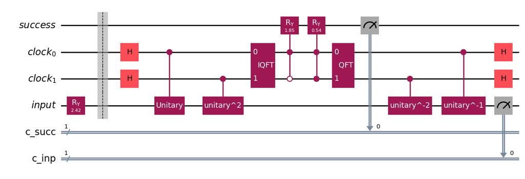

```python
qc.draw(output="mpl")
```

We now execute the circuit and collect measurement outcomes. Since the HHL algorithm succeeds only when the success ancilla is measured in the state $|1\rangle$, we post-select on runs with `c_succ = 1`. From these runs, we compute the empirical frequencies of measuring $0$ and $1$ on the input register, which correspond to the components of the solution state $|x\rangle$.

```python
# Select the Aer qasm simulator backend and transpile the circuit
backend = Aer.get_backend("qasm_simulator")
tqc = transpile(qc, backend)

# Run the transpiled circuit
result = backend.run(tqc, shots=10000).result()

# Retrieve raw measurement counts from the executed circuit
counts = result.get_counts(tqc)

# Post-select on success = 1 and count input outcomes
input_counts = {"0": 0, "1": 0}

for bitstring, count in counts.items():
    # Bitstring groups follow Qiskit's classical-register display order:
    # here "c_inp c_succ", so we unpack as (inp, succ)
    inp, succ = bitstring.split()
    if succ == "1":
        input_counts[inp] += count

n_success = input_counts["0"] + input_counts["1"]

# Conditional probabilities for the solution register
p0 = input_counts["0"] / n_success
p1 = input_counts["1"] / n_success

# Amplitude magnitudes of the solution state |x> = alpha|0> + beta|1>
alpha = np.sqrt(p0)
beta  = np.sqrt(p1)

x_quantum = np.array([alpha, beta])
print(x_quantum)
```

```
[0.76891789 0.63934754]
```

Recall that we previously computed the normalized classical solution,

```python
print(x_classical_state)
```

```
[0.77307406+0.j 0.63431577+0.j]
```

As expected, the normalized classical solution and the solution reconstructed from the HHL circuit are nearly identical. To quantify this agreement, we compute the fidelity between the two states, where values closer to $1$ indicate higher similarity.

```python
F = state_fidelity(x_quantum, x_classical_state)
print("Fidelity =", F)
```

```
Fidelity = 0.9999574080410533
```

In our implementation so far, we have focused on reconstructing the solution state $|x\rangle$ and did not analyze the probability of successfully measuring the ancilla qubit in the state $|1\rangle$. We now examine that success probability.

```python
# Total number of shots
total_shots = sum(counts.values())

# Number of shots with success ancilla measured as 1
success_ones = 0
for bitstring, count in counts.items():
    inp, succ = bitstring.split()
    if succ == "1":
        success_ones += count

p_success = success_ones / total_shots

print(f"P(success = 1) = {p_success:.4f} ({100*p_success:.2f}%)")
```

```
P(success = 1) = 0.2373 (23.73%)
```

We see that the success probability is relatively low, approximately 23%. This probability can be increased by repeating the HHL iteration block, $\mathrm{QPE} - U_{\text{ContRot}} - \mathrm{QPE}^\dagger$. Repeating this unitary block leads to an oscillatory success probability. This behavior is similar in spirit to Grover's algorithm and amplitude amplification. Heuristically repeating the block a number of times on the order of the condition number $\kappa$ of the input matrix $A$ can help identify iterations with higher success probability.

To do so, we implement the HHL iteration block as a function and use it to construct HHL circuits with a variable number of repeated iteration blocks. We then collect statistics on the frequency of measuring $1$ on the success ancilla as the number of HHL iteration blocks increases, and visualize this dependence.

```python
def hhl_iteration_block(qc, *, success, clock, inp, U_gate, phi0, phi1):
    """Append  HHL iteration: QPE -> controlled rotation -> inverse QPE."""
    iqft = synth_qft_full(num_qubits=2, inverse=True,  name="IQFT")
    qft  = synth_qft_full(num_qubits=2, inverse=False, name="QFT")

    qc.h(clock)
    qc.append(U_gate.control(1),              [clock[0], inp[0]])
    qc.append(U_gate.power(2).control(1),     [clock[1], inp[0]])
    qc.append(iqft, clock);

    qc.append(RYGate(phi0).control(2, ctrl_state="01"),
              [clock[0], clock[1], success[0]])
    qc.append(RYGate(phi1).control(2, ctrl_state="11"),
              [clock[0], clock[1], success[0]]);

    qc.append(qft, clock);
    qc.append(U_gate.power(-2).control(1),    [clock[1], inp[0]])
    qc.append(U_gate.power(-1).control(1),    [clock[0], inp[0]])
    qc.h(clock)


def hhl_circuit_with_repetitions(num_iterations, *, A, phi_b, M=0.2, lam0=0.25, lam1=0.75, t=2*np.pi):
    success = QuantumRegister(1, name="success")
    clock   = QuantumRegister(2, name="clock")
    inp     = QuantumRegister(1, name="input")
    c_succ  = ClassicalRegister(1, name="c_succ")
    c_inp   = ClassicalRegister(1, name="c_inp")

    qc = QuantumCircuit(success, clock, inp, c_succ, c_inp)

    qc.append(RYGate(phi_b), [inp[0]])
    qc.barrier(success, clock, inp)

    U_mat  = expm(1j * A * t)
    U_gate = UnitaryGate(U_mat)

    phi0 = 2 * np.arcsin(M / lam0)
    phi1 = 2 * np.arcsin(M / lam1)

    for i in range(num_iterations):
        hhl_iteration_block(qc, success=success, clock=clock, inp=inp, U_gate=U_gate, phi0=phi0, phi1=phi1)

    qc.measure(success[0], c_succ[0])
    qc.measure(inp[0],     c_inp[0]);
    return qc


def success_probability(counts):
    total = sum(counts.values())
    ones = 0
    for bitstring, ct in counts.items():
        inp_bit, succ_bit = bitstring.split()
        if succ_bit == "1":
            ones += ct
    return ones / total
```

```python
# --- Sweep iterations and plot P(success=1) ---
backend = Aer.get_backend("qasm_simulator")

shots = 1000
num_iterations = 40

iteration_counts = list(range(1, num_iterations + 1))
success_probabilities = []

for num_iters in iteration_counts:
    hhl_circuit = hhl_circuit_with_repetitions(num_iters, A=A, phi_b=phi)
    transpiled_circuit = transpile(hhl_circuit, backend)
    result = backend.run(transpiled_circuit, shots=shots).result()
    counts = result.get_counts(transpiled_circuit)
    success_probabilities.append(success_probability(counts))
```

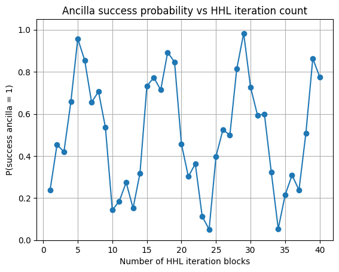

```python
plt.figure()
plt.plot(iteration_counts, success_probabilities, marker="o")

plt.xlabel("Number of HHL iteration blocks")
plt.ylabel("P(success ancilla = 1)")

ax = plt.gca()
ax.xaxis.set_major_locator(MaxNLocator(integer=True))

plt.title("Ancilla success probability vs HHL iteration count")
plt.ylim(0, 1.05)
plt.grid(True)
plt.show()
```

The oscillatory behavior of the success probability is evident from the plot. Repeating the HHL iteration block a small number of times increases the likelihood of measuring the success ancilla in the state $|1\rangle$, while repeating it too many times leads to a decrease before the pattern repeats. Repeating the HHL block therefore introduces a trade-off between success probability and computational cost. Each HHL iteration block contains a QPE subroutine, which is a resource-intensive operation, particularly in the NISQ era, and repeating this block increases circuit depth and overhead. However, higher success probabilities mean that a larger fraction of measurement shots can be used to extract information about the solution state $|x\rangle$. Conversely, if the HHL circuit is executed only once, many more shots are required overall, since a large fraction of runs are discarded during post-selection. Choosing the number of HHL iteration blocks thus involves balancing circuit depth against post-selection efficiency.

### Conclusion

The HHL algorithm is a quantum algorithm that provides exponential speedup for collecting statistical information without solving the entire solution to a linear system of equations $Ax=b$. The algorithm is makes various assumption about the input such as efficient encoding of the state $|b\rangle$ and condition number and sparsitiy of $A$. The algorithm makes use of QPE, controlled rotation which performs the eigenvalue inversion and inverse of QPE operation to distangle the clock register from the input register. Additionally, the output of the algorithm is a quantum state with selected measurmenet to be determined by the usecase under study or use the algorithm as a subroutine. Reconstructing the full normalized solution, while possible, will vanish the quantum advantage. On this note, the work of Scott Aaranson [Quantum Machine Learning Algorithms: Read the Fine Print](https://www.scottaaronson.com/papers/qml.pdf) is relevant, where the paper points out the constant trade off between claims of quantum advantage and the caveats they make, the constant tension between what is theoretically possible and what is practical. The claim "The HHL algorithm solves any linear systems of equations exponentially faster" is simply not true, hence why reading the fine prints is important. That said, the algorithm shows great novelty and paves the path for many applications of quantum computing as discussed. Sometimes the utility of an algorithm is not immediately apparent, but instead represents a small step toward climbing a mountain. Over time, such steps contribute to the overall progress of the field. To keep going, one must have the belief that it will eventually work out. It requires a leap of faith!

### Appendix 1: Clock Register Nomenclature

In the literature, the register that encodes eigenphases in the HHL algorithm is often referred to as the *clock register*, for example in [Quantum Linear Systems Algorithm: A primer](https://arxiv.org/abs/1802.08227) and [An Early Investigation of the HHL Quantum Linear Solver for Scientific Applications](https://arxiv.org/abs/2404.19067). However, the original HHL paper does not explicitly use the term "clock register". Other works, such as [Detailed Error Analysis of the HHL Algorithm](https://arxiv.org/abs/2401.17182), call it the *phase register*. Both naming conventions appear in the literature.

The origin of the term "clock register" can be traced back to foundational ideas in quantum computing, particularly the close connection between Hamiltonian evolution and time. In [Space-Time Circuit-to-Hamiltonian Construction and Its Applications](https://arxiv.org/abs/1311.6101), Breuckmann and Terhal cite Richard Feynman's *Quantum Mechanical Computers*, Optics News, 11:11-20 (1985), in which Feynman proposed simulating a quantum circuit via unitary dynamics generated by a time-independent Hamiltonian. In this construction, one introduces an additional register $|t\rangle$ whose basis states label discrete time steps of the computation. For a circuit consisting of $L$ unitary gates $U_1, \dots, U_L$, the Hamiltonian is constructed as $$ H_t = U_t \otimes |t\rangle\langle t-1| + U_t^\dagger \otimes |t-1\rangle\langle t|, \qquad H = \sum_{t=1}^{L} H_t. $$

In the HHL algorithm, controlled time-evolution $e^{iAt}$ is applied as part of quantum phase estimation. The parameter $t$ is not used only once at a fixed value. Instead, one chooses a base time step $t_0$ and applies controlled evolutions of the form $e^{iA 2^{j} t_0}$, where $j$ indexes the qubits of the phase-estimation register. In this sense, the register labels discrete evolution times, and the "clock register" terminology reflects its role as a discrete time counter within the algorithm.

The sine-weighted initial state used in HHL, $$ |\Psi_0\rangle = \sqrt{\frac{2}{T}} \sum_{\tau=0}^{T-1} \sin\left(\frac{\pi\left(\tau + \frac{1}{2}\right)}{T}\right) |\tau\rangle, $$ is chosen (following [5,7] in the original HHL paper) to optimize phase-estimation accuracy. In particular, V. Bužek, R. Derka, and S. Massar, [Optimal quantum clocks](https://arxiv.org/pdf/quant-ph/9808042) analyze optimal quantum states for estimating phase evolution under a known Hamiltonian. In that metrological setting, one considers states evolving as $$ |\psi(t)\rangle = e^{-iHt}|\psi(0)\rangle = e^{-i\lambda t}|\psi(0)\rangle. $$ If $t$ is known, one estimates $\lambda$; if $\lambda$ is known, one estimates $t$. These two viewpoints are connected, since the physically relevant quantity is the accumulated phase $\lambda t$. In quantum algorithms such as Hamiltonian simulation, QPE, and HHL, one typically assumes $t$ is chosen by the algorithm and estimates $\lambda$. In quantum metrology, one typically assumes $\lambda$ is known and estimates $t$.

For this reason, the terminology "clock register" emphasizes the register's interpretation as discretized time in Hamiltonian evolution, whereas "phase register" more directly reflects its operational role of encoding eigenphase information. Both terms are used in the literature, and the difference is largely pedagogical rather than technical.

### Appendix 2: Biography

- Seth Lloyd, born in 1960, is an American scientist. He obtained his undergraduate and graduate degrees in physics and mathematics from [Harvard University and the University of Cambridge](https://meche.mit.edu/sites/default/files/cv/slloyd_CV.pdf). He later obtained a Doctor of Philosophy degree from Rockefeller University with the dissertation titled [Black holes, demons and the loss of coherence: how complex systems get information and what they do with it](https://search.worldcat.org/title/Black-holes-demons-and-the-loss-of-coherence%3A-how-complex-systems-get-information-and-what-they-do-with-it/oclc/38086490). His research interests are in quantum information science.

  He has spent the majority of his academic career at MIT, has authored and co-authored over 150 publications, and has received various awards, including the Harold E. Edgerton Faculty Achievement Award, which MIT describes as awarded "to recognize exceptional distinction in teaching, in research, and in service" (see https://facultygovernance.mit.edu/committee/harold-e-edgerton-faculty-achievement-award-selection-committee).
- Aram W. Harrow, born in 1980, is an American scientist. He obtained his undergraduate degree in mathematics and physics in 2001 and his Doctor of Philosophy degree in 2005, both from the MIT. His doctoral thesis was titled [Applications of Coherent Classical Communication and the Schur Transform to Quantum Information Theory](https://dspace.mit.edu/handle/1721.1/34973). After completing his doctorate, he held positions at the University of Bristol and the University of Washington before returning to MIT in 2013. His research areas include theoretical quantum information science and quantum algorithms. He has received various awards, including the 2018 [Rolf Landauer and Charles H. Bennett Award in Quantum Computing](https://www.aps.org/funding-recognition/award/landauer-bennett), awarded "for outstanding accomplishments in the mathematics of quantum information, and the development of new algorithmic primitives for quantum computers."
- Avinatan Hassidim is a theoretical computer scientist who obtained his undergraduate and master's degrees in 2001, and his PhD degree in 2009, all from the Hebrew University of Jerusalem. His doctoral thesis was titled [Algorithmic Applications of Quantum Entanglement](https://research-students.huji.ac.il/en/hassidim). He held position at [Israel's Bar-Ilan University](https://orcid.org/0000-0002-3855-344X) and, as of 2025, serves as Vice President of Research at Google (see https://blog.google/company-news/outreach-and-initiatives/google-org/deepening-our-ai-research-partnership-with-tel-aviv-university/).

### Appendix 3: References and Suggested Readings

1. Harrow, Aram W.; Hassidim, Avinatan; & Lloyd, Seth. (2009). Quantum algorithm for linear systems of equations. Physical Review Letters. DOI: 10.1103/PhysRevLett.103.150502. [[arXiv](https://arxiv.org/abs/0811.3171)].
2. Dervovic, Danial; Herbster, Mark; Mountney, Peter; Severini, Simone; Usher, Naïri; & Wossnig, Leonard. (2018). Quantum linear systems algorithms: a primer. [arXiv:1802.08227](https://arxiv.org/abs/1802.08227).
3. Zheng, Muqing; Liu, Chenxu; Stein, Samuel; Li, Xiangyu; Mülmenstädt, Johannes; Chen, Yousu; & Li, Ang. (2025). An early investigation of the HHL quantum linear solver for scientific applications. Algorithms, 18 (8), Article 491. DOI: [10.3390/a18080491](https://www.mdpi.com/1999-4893/18/8/491). [[arXiv](https://arxiv.org/abs/2404.19067)].
4. Galvão, Lucas Q.; de Souza, Anna Beatriz M.; Santos, Alexandre Oliveira S.; Sousa, André Saimon S.; & Cruz, Clebson. (2026). Solving linear systems of equations with the quantum HHL algorithm: a tutorial on the physical and mathematical foundations for undergraduate students. [arXiv:2509.16640](https://arxiv.org/abs/2509.16640).
5. Kotil, Ayse. (2021). Classical reinforcement learning using quantum algorithms. Bachelor's thesis, Technische Universität München. Available at: https://mediatum.ub.tum.de/doc/1610762/4rcz2u1o0h61wji7mimto382h.BA-Kotil.pdf
6. Greenaway, Sean; Pol, William; & Sim, Sukin. (2024). A case study against QSVT: assessment of quantum phase estimation improved by signal processing techniques. [arXiv:2404.01396](https://arxiv.org/abs/2404.01396).
7. Apel, Harriet; Cortes, Cristian L.; Lemieux, Jessica; & Steudtner, Mark. (2025). Reducing quantum resources for observable estimation with window‑assisted coherent QPE. [arXiv:2508.06677](https://arxiv.org/abs/2508.06677).
8. Carrera Vazquez, Almudena; Hiptmair, Ralf; & Woerner, Stefan. (2022). Enhancing the quantum linear systems algorithm using Richardson extrapolation. ACM Transactions on Quantum Computing. DOI: 10.1145/3490631. [[arXiv](https://arxiv.org/abs/2009.04484)].
9. Valiron, B. (2025). Introduction to quantum algorithms and quantum programming (Course notes v.2025‑03‑04). Available at: https://www.monoidal.net/qnotes-2025-03-04.pdf.
10. University of Pennsylvania CIS 515 Lecture Notes. (2012). Chapter 4: Vector norms and matrix norms. Available at: https://www.cis.upenn.edu/~cis5150/cis515-12-sl4.pdf
11. Scott Aaronson. (2015). Quantum machine learning algorithms: read the fine print. Essay discussing caveats of quantum machine‑learning speedups. Available at: https://www.scottaaronson.com/papers/qml.pdf.
12. Bužek, V.; Derka, R.; & Massar, S. (1999). Optimal quantum clocks. Physical Review Letters. DOI: 10.1103/PhysRevLett.82.2207. [[arXiv](https://arxiv.org/abs/quant-ph/9808042)].
13. Luis, Alfredo; & Peřina, Jaromír. (1996). Optimum phase‑shift estimation and the quantum description of the phase difference. Physical Review A, 54, 4564-4570. DOI: [DOI: 10.1103/PhysRevA.54.4564](https://journals.aps.org/pra/abstract/10.1103/PhysRevA.54.4564).
14. Breuckmann, Nikolas P.; & Terhal, Barbara M. (2014). Space‑time circuit‑to‑Hamiltonian construction and its applications. Journal of Physics A: Mathematical and Theoretical. DOI: 10.1088/1751-8113/47/19/195304. [[arXiv](https://arxiv.org/abs/1311.6101)].
15. Cleve, Richard; van Dam, Wim; Nielsen, Michael; & Tapp, Alain. (2013). Quantum entanglement and the communication complexity of the inner product function. Theoretical Computer Science, 486, 11–19. DOI: 10.1016/j.tcs.2012.12.012. [[arXiv](https://arxiv.org/abs/quant-ph/9708019)].
16. Ambainis, Andris. (2012). Variable time amplitude amplification and quantum algorithms for linear algebra problems. In *29th International Symposium on Theoretical Aspects of Computer Science* (STACS 2012), Leibniz International Proceedings in Informatics (LIPIcs), pp. 636-647. DOI: 10.4230/LIPIcs.STACS.2012.636. [[arXiv](https://arxiv.org/abs/1010.4458)].
17. Childs, Andrew M.; Kothari, Robin; & Somma, Rolando D. (2017). Quantum algorithm for systems of linear equations with exponentially improved dependence on precision. SIAM Journal on Computing, 1920-1950. DOI: 10.1137/16M1087072. [[arXiv](https://arxiv.org/abs/1511.02306)].
18. Montanaro, Ashley; & Pallister, Sam. (2016). Quantum algorithms and the finite element method. Physical Review A, DOI: 10.1103/PhysRevA.93.032324. [[arXiv](https://arxiv.org/abs/1512.05903)].
19. Cao, Yudong; Papageorgiou, Anargyros; Petras, Iasonas; Traub, Joseph; & Kais, Sabre. (2013). Quantum algorithm and circuit design solving the Poisson equation. New Journal of Physics. DOI: 10.1088/1367-2630/15/1/013021. [[arXiv](https://arxiv.org/abs/1207.2485)].
20. Linden, Noah; Montanaro, Ashley; & Shao, Changpeng. (2022). Quantum vs. classical algorithms for solving the heat equation. Communications in Mathematical Physics, 395, 601–641. DOI: 10.1007/s00220-022-04442-6. [[arXiv](https://arxiv.org/abs/2004.06516)].
21. Rebentrost, Patrick; & Lloyd, Seth. (2024). Quantum computational finance: quantum algorithm for portfolio optimization. KI - Künstliche Intelligenz, 38, 327-338. DOI: 10.1007/s13218-024-00870-9. [[arXiv](https://arxiv.org/abs/1811.03975)].
22. EmergentMind. (2025). Quantum linear solver. Available at: https://www.emergentmind.com/topics/quantum-linear-solver

#### Tutorials

23. René Zander, Raphael Seidel & Matic Petrič. (2025). Solving systems of linear equations via HHL using Qrisp and Catalyst. PennyLane Demos (published Feb 26 2025, updated Nov 10 2025). Available at: https://pennylane.ai/qml/demos/linear_equations_hhl_qrisp_catalyst.
24. IBM Quantum Documentation. (n.d.) PiecewiseChebyshev class - part of Qiskit's circuit library. Available at: https://quantum.cloud.ibm.com/docs/en/api/qiskit/qiskit.circuit.library.PiecewiseChebyshev.
25. Qiskit Textbook Team. (2023). Solving linear systems of equations using HHL and its Qiskit implementation. In Qiskit Textbook, chap. "Applications - HHL tutorial." Available on GitHub: [https://github.com/Qiskit/textbook/blob/main/notebooks/ch-applications/hhl_tutorial.ipynb](https://github.com/Qiskit/textbook/blob/aebdd2bc86ddb7a79dd8441d52c839d312ffafbb/notebooks/ch-applications/hhl_tutorial.ipynb).
26. dreamingangela. (2019). ibmq_hhl: simple QASM code to demonstrate the HHL algorithm on IBM Q. GitHub repository. Available on GitHub: [https://github.com/dreamingangela/ibmq_hhl](https://github.com/dreamingangela/ibmq_hhl/blob/57b6b72810f02e8bf41c606cec355c56b32625ed/hhl.qasm).
27. Classiq Library Team. (2019). HHL algorithm notebook (hhl.ipynb). Available on GitHub: [https://github.com/Classiq/classiq-library/blob/main/algorithms/quantum_linear_solvers/hhl/hhl.ipynb](https://github.com/Classiq/classiq-library/blob/d9f2537cae8db71d69598726fab2932a89718495/algorithms/quantum_linear_solvers/hhl/hhl.ipynb).